# marshmallow

uoepsy

2022-11-28

https://edin.ac/3F7y8Vq

# 1. Research aims

200 children between the ages of 3 and 7 years old took part in a study aiming replicate the Stanford Marshmallow Experiment, in which the experimenter shows a marshmallow to the child and explains that they (the experimenter) is about to leave the room for 40 minutes. They explain to the child that they are welcome to eat the marshmallow while they are waiting, but *if* the marshmallow is still there after 40 minutes, they will get *two* marshmallows as a reward. In the “hidden” condition, the marshmallow is placed in an opaque box on a table. In the “visible” condition, the marshmallow is placed on a plate.

The original study found that older children were more likely to wait the full time for two marshmallows. It also found that the visibility of the marshmallow was associated with taking the immediate (but smaller) reward of only one marshmallow, but that this was reduced for older children.

Researchers record *if* each child takes the marshmallow while the experimenter is away, and for those that do, how long (in minutes) they manage before taking it.

Their aims are twofold:

- to assess whether the results of the original study are present even *after* accounting for individual differences in how much children like sweet things (as rated by a questionnaire administered to their parents).
- to investigate whether the same pattern of results is evident in the ‘time taken to give in’ for the children who do not manage to wait for the experimenter’s return

# taking the marshmallow

- to assess whether the results of the original study are present even *after* accounting for individual differences in how much children like sweet things (as rated by a questionnaire administered to their parents).

# time taken (for those who took it)

> The original study found that older children were more likely to wait the full time for two marshmallows. It also found that the visibility of the marshmallow was associated with taking the immediate (but smaller) reward of only one marshmallow, but that this was reduced for older children.
- to investigate whether the same pattern of results is evident in the ‘time taken to give in’ for the children who do not manage to wait for the experimenter’s return

Time (in minutes) to take the marshmallow was modelled using linear regression, with sweet-ratings (Z-scored), age (in months, centered at 36), marshmallow visibility (visible vs hidden, treatment coded with hidden as the reference level), and the interaction between age and visibility. Bootstrapped confidences (with 2000 iterations) were obtained for all coefficients.  
Results indicate that after accounting for how much children like sweet foods, when the marshmallow was hidden from sight, being one month older was not significantly associated with managing to last any more time before taking the marshmallow (95% bootstrapped CI [-0.02, 0.29]). A significant interaction was found between age and visibility: the older children were, the more visibility of the marshmallow *increased* time taken before eating the marshmmallow (0.2 [0.03, 0.36]). This relationship (visualised in Figure 1) is conceptually at odds with the pattern of results in previous studies examining predictors of taking vs not taking the marshmallow.

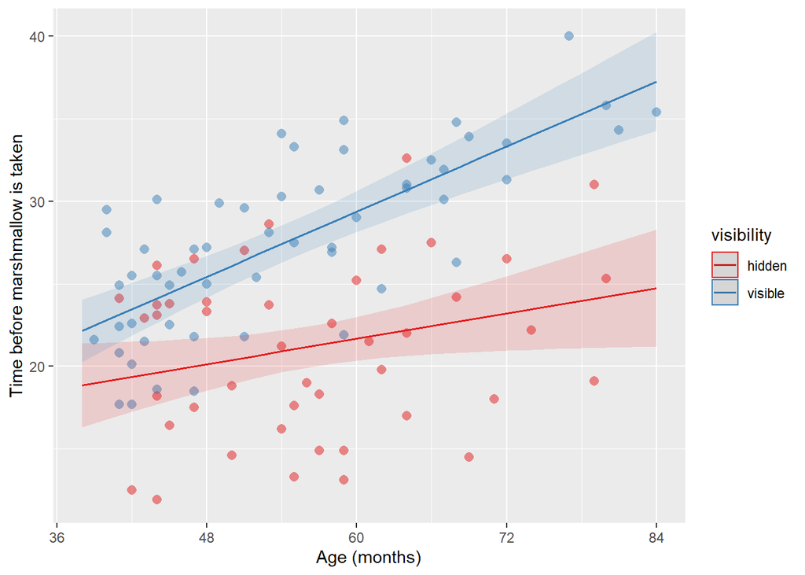

Figure 1: interaction between age and visibility